# Climate Change Impacts on Poultry Farming in Imota, Lagos, Nigeria

## Introduction:

##### Climate change poses significant challenges to agricultural sectors worldwide, including poultry farming. In Imota, Lagos, Nigeria, where poultry farming plays a crucial role in food security and economic development, understanding the impact of climate change is vital. This study aims to investigate the specific effects of climate change on poultry farming in Imota, focusing on animal behaviors, welfare, and production. By examining these factors, we can identify vulnerabilities and develop strategies to enhance the resilience of poultry farms in the face of changing climatic conditions. This research contributes to informed decision-making and sustainable planning for the poultry sector in Imota and beyond

##### To conduct our analysis, we will utilize various Python libraries that provide powerful tools for data manipulation, analysis, and visualization. The following libraries will be imported:

```python
import pandas as pd
import numpy as np
import scipy.stats as stats
import matplotlib.pyplot as plt
import seaborn as sns
from tabulate import tabulate
from scipy.stats import chi2_contingency
```

```python
import warnings
warnings.filterwarnings('ignore')
```

```python
# Step 1: Data Preparation
df = pd.read_csv(r"C:\Users\DAMMY\Desktop\datascience\thePoultry.csv")
df
```

|  | Establishment | Farm _Location | Education_Level | Gender | Production_system | Farm_Size | Years _in _Farming | Egg _Preference | Climate_Changes _Observed | Observed _Changes _Increased _Temperature | Observed _Changes _Decreased _Rainfall | Observed _Changes _ Extreme _Weather _Events | Any _Smart _Solutions _Implemented | Implemented _Smart _Solutions | Impact _on _Water _Availability | Impact _on _Bird _Health _and _Productivity | Future _of _Poultry _Farming | Government _Support _Climate _Change_ Adaptation | Other_ Climate _Change _Impacts | Additional _Information |
| --- | --- | --- | --- | --- | --- | --- | --- | --- | --- | --- | --- | --- | --- | --- | --- | --- | --- | --- | --- | --- |
| 0 | Latwins Farms Ltd | Lagos, Nigeria | Master's degree | male | Egg+Meat | More than 5000 birds | More than 10 years | Brown eggs | Yes | True | True | True | No | Shade structures | no | Negatively | bad | No | Non | Data on climate changes and its effects need t... |
| 1 | Barinda Farms | Lagos State | Bachelor's degree | male | Egg | 1000-5000 birds | 5-10 years | Brown eggs | No | NaN | NaN | NaN | Yes | Use of renewable energy sources | no | Negatively | good | Uncertain | No | No |
| 2 | Amazon Farms | Lagos State | High school diploma | male | Egg | Less than 500 birds | 5-10 years | Brown eggs | Yes | True | True | NaN | No | NaN | no | Other (please specify):Low production of eggs | bad | Uncertain | No | NaN |
| 3 | IRRIGATE AGRO | Ogun State | Bachelor's degree | male | Egg | More than 5000 birds | 5-10 years | Brown eggs | No | True | NaN | True | No | Shade structures | yes | Negatively | good | No | NaN | No |
| 4 | Nike Farms | Lagos State | Other (please specify):HND | female | Egg | Less than 500 birds | 2-5 years | Brown eggs | Yes | True | NaN | True | No | Shade structures | no | Negatively | good | No | Very cold weather ( harmattan | Poultry farmers should be exposed to modern me... |
| ... | ... | ... | ... | ... | ... | ... | ... | ... | ... | ... | ... | ... | ... | ... | ... | ... | ... | ... | ... | ... |
| 57 | Raphael Farm | Lagos State | High school diploma | male | Egg | Less than 500 birds | 2-5 years | Brown eggs | Yes | NaN | True | True | Yes | Other (please specify):Heating vents | yes | Negatively | good | Yes | No other ways | No |
| 58 | Mia finger food | Lagos State | Bachelor's degree | male | Egg+Meat | 1000-5000 birds | 2-5 years | Brown eggs | Yes | True | NaN | True | Yes | Improved ventilation systems | yes | Other (please specify):Disease infestation. | good | No | The availability of farm feeds | None |
| 59 | Olaluwa poultry farming | Lagos State | Bachelor's degree | male | Egg+Meat | 1000-5000 birds | 5-10 years | Brown eggs | Yes | True | NaN | True | Yes | Shade structures | yes | Negatively | good | No | Inaccessibility of the farm Incases of overflo... | None |
| 60 | Vip Tech and farms | Ogun State | Other (please specify):NCE | male | Egg+Meat | Less than 500 birds | 2-5 years | No preference | Yes | True | True | NaN | Yes | Shade structures | no | Positively | good | Yes | Cold on the smaller birds when it’s raining | Diseases |
| 61 | Bishe Organic Farm | Others | Master's degree | female | Egg+Meat | 1000-5000 birds | 5-10 years | No preference | Yes | True | True | True | Yes | Shade structures | no | No significant effect | bad | No | Survival of the chickens in the farm during th... | None for now |

62 rows × 20 columns

```python
# Assuming the dataset is stored in a DataFrame called df
# Drop irrelevant columns
df = df.drop(columns=['Additional _Information'])
```

```python
df.columns
```

```
Index(['Establishment', 'Farm _Location ', 'Education_Level', 'Gender',
       'Production_system', 'Farm_Size', 'Years _in _Farming',
       'Egg _Preference', 'Climate_Changes _Observed',
       'Observed _Changes _Increased _Temperature',
       'Observed _Changes _Decreased _Rainfall',
       'Observed _Changes _ Extreme _Weather _Events',
       'Any _Smart _Solutions _Implemented', 'Implemented _Smart _Solutions',
       'Impact _on _Water _Availability',
       'Impact _on _Bird _Health _and _Productivity',
       'Future _of _Poultry _Farming',
       'Government _Support _Climate _Change_ Adaptation',
       'Other_ Climate _Change _Impacts'],
      dtype='object')
```

```python
# Convert columns to categorical data type
categorical_cols = ['Farm _Location', 'Education_Level', 'Gender', 'Production_system', 'Egg _Preference',
                    'Climate_Changes _Observed', 'Observed _Changes _Increased _Temperature',
                    'Observed _Changes _Decreased _Rainfall', 'Observed _Changes _ Extreme _Weather _Events',
                    'Any _Smart _Solutions _Implemented', 'Implemented _Smart _Solutions',
                    'Impact _on _Water _Availability', 'Impact _on _Bird _Health _and _Productivity',
                    'Future _of _Poultry _Farming', 'Government _Support _Climate _Change_ Adaptation']
```

### Categorize the columns

```python
# Drop irrelevant columns
# Categorize the columns
welfare_columns = [
    "Climate_Changes_Observed",
    "Observed_Changes_Increased_Temperature",
    "Observed_Changes_Decreased_Rainfall",
    "Observed_Changes_Extreme_Weather_Events",
    "Implemented_Smart_Solutions",
    "Impact_on_Water_Availability",
    "Impact_on_Bird_Health_and_Productivity",
    "Other_Climate_Change_Impacts",
]

behavior_columns = [ "Implemented_Smart_Solutions",

    "Future_of_Poultry_Farming",
    "Additional_Information",
]

production_columns = [
    "Farm_Size",
    "Years_in_Farming",
    "Egg_Preference",
    "Any_Smart_Solutions_Implemented",
]
```

## Descriptive Analysis of the categorized columns

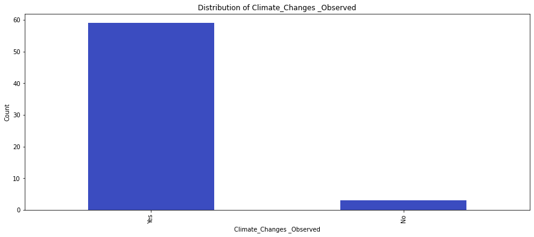

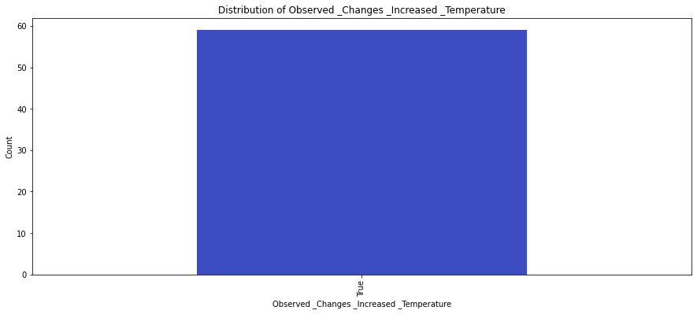

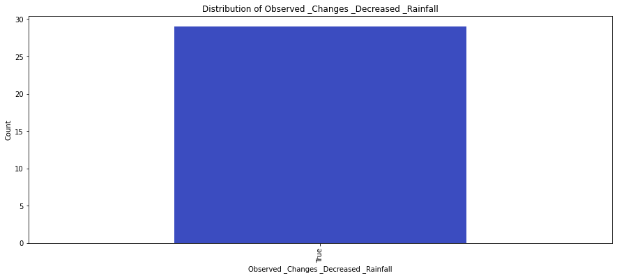

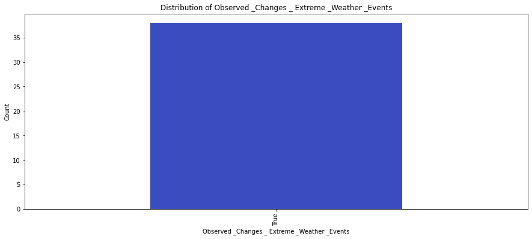

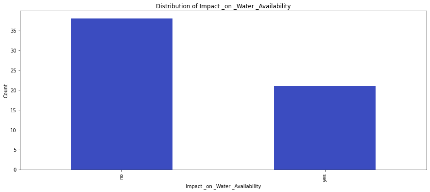

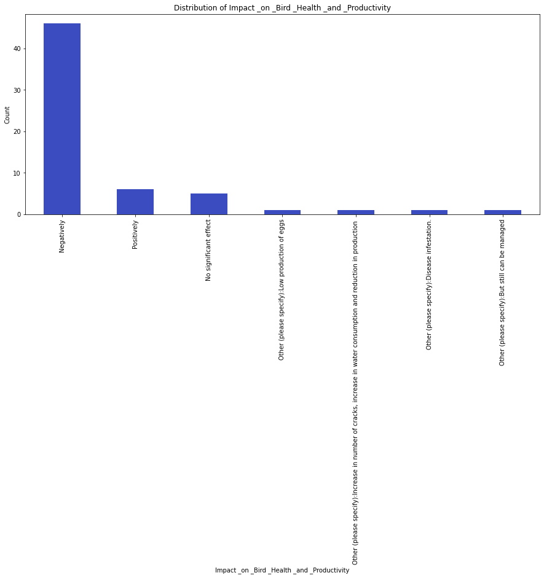

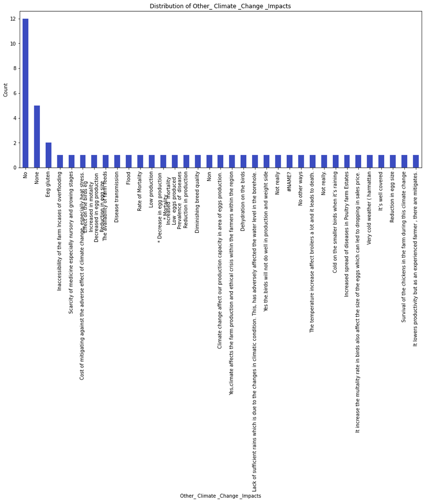

```python
welfare_columns = [
    "Climate_Changes _Observed",
    "Observed _Changes _Increased _Temperature",
    "Observed _Changes _Decreased _Rainfall",
    "Observed _Changes _ Extreme _Weather _Events",
    "Impact _on _Water _Availability",
    "Impact _on _Bird _Health _and _Productivity",
    "Other_ Climate _Change _Impacts",
]

for column in welfare_columns:
    plt.figure(figsize=(15, 6))
    df[column].value_counts().plot(kind='bar', colormap='coolwarm')
    plt.xlabel(column)
    plt.ylabel('Count')
    plt.title('Distribution of ' + column)
    plt.show()
```

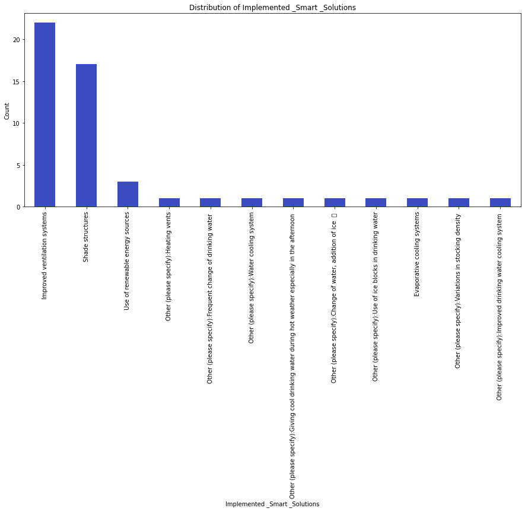

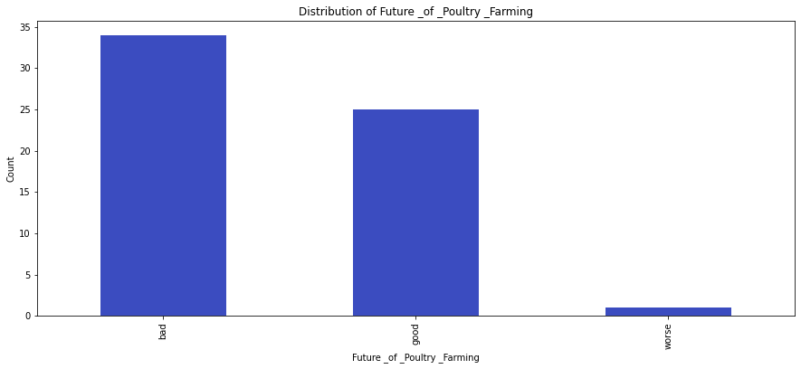

```python
behavior_columns = ['Implemented _Smart _Solutions', 'Future _of _Poultry _Farming']

for column in behavior_columns:
    plt.figure(figsize=(15, 6))
    df[column].value_counts().plot(kind='bar', colormap='coolwarm')
    plt.xlabel(column)
    plt.ylabel('Count')
    plt.title('Distribution of ' + column)
    plt.show()
```

```python
df.columns
```

```
Index(['Establishment', 'Farm _Location ', 'Education_Level', 'Gender',
       'Production_system', 'Farm_Size', 'Years _in _Farming',
       'Egg _Preference', 'Climate_Changes _Observed',
       'Observed _Changes _Increased _Temperature',
       'Observed _Changes _Decreased _Rainfall',
       'Observed _Changes _ Extreme _Weather _Events',
       'Any _Smart _Solutions _Implemented', 'Implemented _Smart _Solutions',
       'Impact _on _Water _Availability',
       'Impact _on _Bird _Health _and _Productivity',
       'Future _of _Poultry _Farming',
       'Government _Support _Climate _Change_ Adaptation',
       'Other_ Climate _Change _Impacts'],
      dtype='object')
```

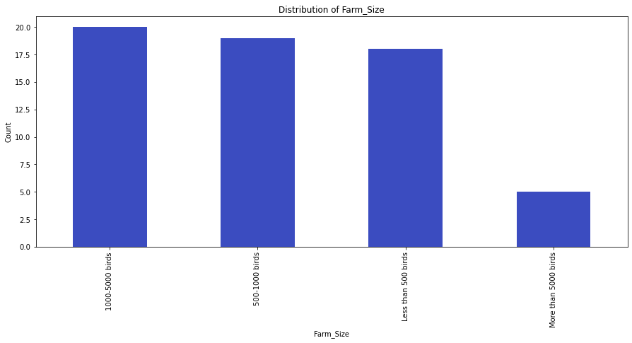

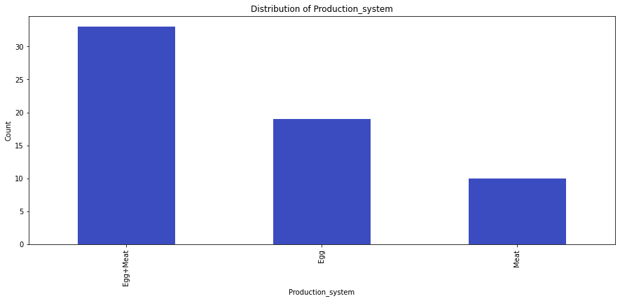

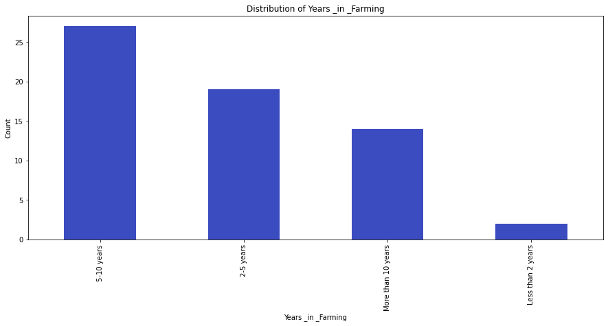

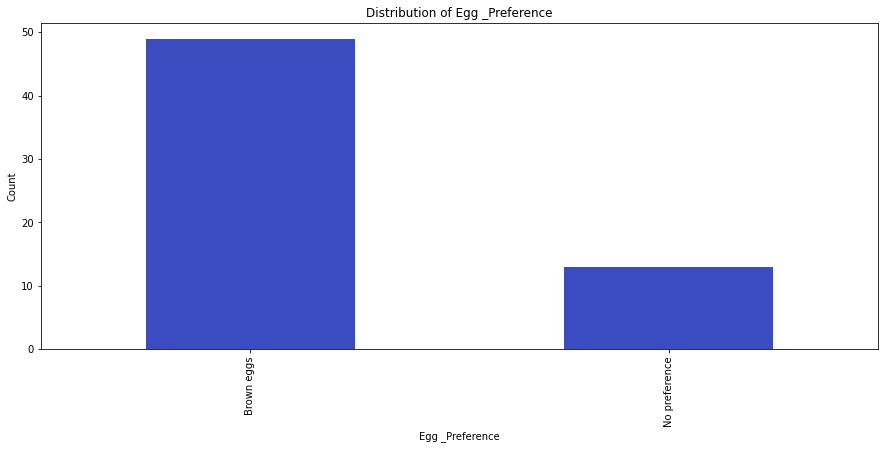

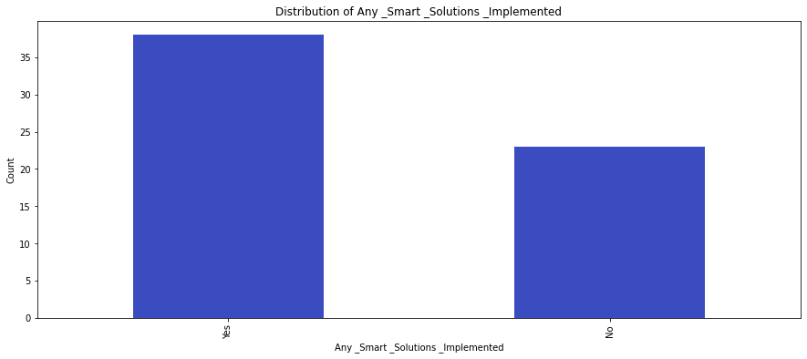

```python
production_columns = [
    "Farm_Size",
    'Production_system',
    "Years _in _Farming",
    "Egg _Preference",
    "Any _Smart _Solutions _Implemented",
]


for column in production_columns:
    plt.figure(figsize=(15, 6))
    df[column].value_counts().plot(kind='bar', colormap='coolwarm')
    plt.xlabel(column)
    plt.ylabel('Count')
    plt.title('Distribution of ' + column)
    plt.show()
```

# Cross tabulation and Analysis:

- #### Analyze the relationships between variables using chi-square.
- #### Interpret the results and discuss the significance of the correlations.

## Hypothesis 1:

### Farmers' Perspective on the Effect of Climate Change on Poultry Production

- #### Perform chi-square to examine the association between the categorical variable "Climate_Changes_Observed" and the variable "Production_System"
- #### Generate bar plots or stacked bar charts to visualize the distribution of climate change observations across other different production columns

```python
# Hypothesis 1: Farmers' Perspective on the Effect of Climate Change on Poultry Production

# Perform chi-square test between "Climate_Changes_Observed" and "Production_System"
contingency_table = pd.crosstab(df['Climate_Changes _Observed'], df['Production_system'])
chi2, p, _, _ = chi2_contingency(contingency_table)
contingency_table
```

| Production_system Climate_Changes _Observed | Egg | Egg+Meat | Meat |
| --- | --- | --- | --- |
| No | 2 | 1 | 0 |
| Yes | 17 | 32 | 10 |

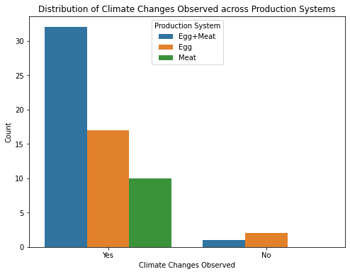

```python
# Visualize the distribution of climate change observations across different production systems
plt.figure(figsize=(8, 6))
sns.countplot(x='Climate_Changes _Observed', hue='Production_system', data=df)
plt.xlabel('Climate Changes Observed')
plt.ylabel('Count')
plt.title('Distribution of Climate Changes Observed across Production Systems')
plt.legend(title='Production System')
plt.show()
```

```python
# Cross-tabulation between climate changes and other production-related variables
for column in production_columns:
    crosstab = pd.crosstab(df["Climate_Changes _Observed"], df[column])
    print(f"Cross-tabulation between Climate Changes Observed and {column}:")
    print("-" * 40)
    print(crosstab)
    print()

    # Perform chi-square test
    chi2, p, _, _ = chi2_contingency(crosstab)
    print(f"Chi-square test p-value: {p:.4f}")
    print("-" * 40)
```

```
Cross-tabulation between Climate Changes Observed and Farm_Size:
----------------------------------------
Farm_Size                  1000-5000 birds  500-1000 birds  \
Climate_Changes _Observed
No                                       1               1
Yes                                     19              18

Farm_Size                  Less than 500 birds  More than 5000 birds
Climate_Changes _Observed
No                                           0                     1
Yes                                         18                     4

Chi-square test p-value: 0.3313
----------------------------------------
Cross-tabulation between Climate Changes Observed and Production_system:
----------------------------------------
Production_system          Egg  Egg+Meat  Meat
Climate_Changes _Observed
No                           2         1     0
Yes                         17        32    10

Chi-square test p-value: 0.3539
----------------------------------------
Cross-tabulation between Climate Changes Observed and Years _in _Farming:
----------------------------------------
Years _in _Farming         2-5 years  5-10 years  Less than 2 years  \
Climate_Changes _Observed
No                                 1           2                  0
Yes                               18          25                  2

Years _in _Farming         More than 10 years
Climate_Changes _Observed
No                                          0
Yes                                        14

Chi-square test p-value: 0.7511
----------------------------------------
Cross-tabulation between Climate Changes Observed and Egg _Preference:
----------------------------------------
Egg _Preference            Brown eggs  No preference
Climate_Changes _Observed
No                                  3              0
Yes                                46             13

Chi-square test p-value: 0.8512
----------------------------------------
Cross-tabulation between Climate Changes Observed and Any _Smart _Solutions _Implemented:
----------------------------------------
Any _Smart _Solutions _Implemented  No  Yes
Climate_Changes _Observed
No                                   2    1
Yes                                 21   37

Chi-square test p-value: 0.6523
----------------------------------------
```

- #### Cross-tabulation between Climate Changes Observed and Farm_Size:

No: 1 (1000-5000 birds), 1 (500-1000 birds), 0 (Less than 500 birds), 1 (More than 5000 birds) Yes: 19 (1000-5000 birds), 18 (500-1000 birds), 18 (Less than 500 birds), 4 (More than 5000 birds) Chi-square test p-value: 0.3313

- #### Cross-tabulation between Climate Changes Observed and Production_system:

No: 2 (Egg), 1 (Egg+Meat), 0 (Meat) Yes: 17 (Egg), 32 (Egg+Meat), 10 (Meat) Chi-square test p-value: 0.3539

- #### Cross-tabulation between Climate Changes Observed and Years_in_Farming:

No: 1 (2-5 years), 2 (5-10 years), 0 (Less than 2 years), 0 (More than 10 years) Yes: 18 (2-5 years), 25 (5-10 years), 2 (Less than 2 years), 14 (More than 10 years) Chi-square test p-value: 0.7511

- #### Cross-tabulation between Climate Changes Observed and Egg_Preference:

No: 3 (Brown eggs), 0 (No preference) Yes: 46 (Brown eggs), 13 (No preference) Chi-square test p-value: 0.8512

- #### Cross-tabulation between Climate Changes Observed and Any_Smart_Solutions_Implemented:

No: 2 Yes: 21 Chi-square test p-value: 0.6523

```python
# Frequency counts and cross-tabulations for socio-economic characteristics
for column in ["Education_Level", "Gender", "Production_system"]:
    counts = df[column].value_counts()
    print(f"Frequency counts for {column}:")
    print(counts)
    print()

    crosstab = pd.crosstab(df[column], df["Climate_Changes _Observed"])
    print(f"Cross-tabulation between {column} and Climate_Changes_Observed:")
    print(crosstab)
    print()

    # Perform chi-square test
    chi2, p, _, _ = chi2_contingency(crosstab)
    print(f"Chi-square test p-value: {p:.4f}")
    print("-" * 40)

# In this modified version, I moved the print statements that display the column name to the beginning of each iteration. Additionally,
# I formatted the p-value to display only four decimal places for better readability. The output will now show the frequency counts, cross-tabulation,
# and the chi-square test p-value for each socio-economic characteristic column.
```

```
Frequency counts for Education_Level:
Bachelor's degree              26
Master's degree                15
High school diploma             9
Doctorate degree                3
Other (please specify):Ssce     2
Associate's degree              2
Other (please specify):HND      2
Other (please specify):NCE      1
Other (please specify):SSCE     1
Other (please specify):OND      1
Name: Education_Level, dtype: int64

Cross-tabulation between Education_Level and Climate_Changes_Observed:
Climate_Changes _Observed    No  Yes
Education_Level
Associate's degree            0    2
Bachelor's degree             2   24
Doctorate degree              0    3
High school diploma           1    8
Master's degree               0   15
Other (please specify):HND    0    2
Other (please specify):NCE    0    1
Other (please specify):OND    0    1
Other (please specify):SSCE   0    1
Other (please specify):Ssce   0    2

Chi-square test p-value: 0.9780
----------------------------------------
Frequency counts for Gender:
male      35
female    27
Name: Gender, dtype: int64

Cross-tabulation between Gender and Climate_Changes_Observed:
Climate_Changes _Observed  No  Yes
Gender
female                      1   26
male                        2   33

Chi-square test p-value: 0.8173
----------------------------------------
Frequency counts for Production_system:
Egg+Meat    33
Egg         19
Meat        10
Name: Production_system, dtype: int64

Cross-tabulation between Production_system and Climate_Changes_Observed:
Climate_Changes _Observed  No  Yes
Production_system
Egg                         2   17
Egg+Meat                    1   32
Meat                        0   10

Chi-square test p-value: 0.3539
----------------------------------------
```

## Hypothesis 2:

### Farmer perspective on the impact of climate change on welfare and behavior of poultry

```python
# Hypothesis 2: Farmer Perspective on the Impact of Climate Change on Welfare and Behavior of Poultry

# Perform chi-square tests between "Climate_Changes_Observed" and welfare/behavior variables
welfare_behavior_vars = ['Observed _Changes _Increased _Temperature', 'Observed _Changes _Decreased _Rainfall',
                         'Observed _Changes _ Extreme _Weather _Events',
                         'Impact _on _Water _Availability', 'Impact _on _Bird _Health _and _Productivity']
p_values = []
for var in welfare_behavior_vars:
    contingency_table = pd.crosstab(df['Climate_Changes _Observed'], df[var])
    chi2, p, _, _ = chi2_contingency(contingency_table)
    p_values.append(p)
    print(f"p-value for {var}: {p}")
contingency_table
```

```
p-value for Observed _Changes _Increased _Temperature: 1.0
p-value for Observed _Changes _Decreased _Rainfall: 1.0
p-value for Observed _Changes _ Extreme _Weather _Events: 1.0
p-value for Impact _on _Water _Availability: 0.7502320850074202
p-value for Impact _on _Bird _Health _and _Productivity: 0.8934158040881375
```

| Impact _on _Bird _Health _and _Productivity Climate_Changes _Observed | Negatively | No significant effect | Other (please specify):But still can be managed | Other (please specify):Disease infestation. | Other (please specify):Increase in number of cracks, increase in water consumption and reduction in production | Other (please specify):Low production of eggs | Positively |
| --- | --- | --- | --- | --- | --- | --- | --- |
| No | 2 | 0 | 0 | 0 | 0 | 0 | 1 |
| Yes | 44 | 5 | 1 | 1 | 1 | 1 | 5 |

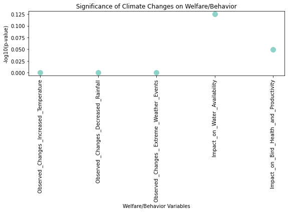

```python
import matplotlib.pyplot as plt

# Define the welfare/behavior variables and corresponding p-values
welfare_behavior_vars = ['Observed _Changes _Increased _Temperature', 'Observed _Changes _Decreased _Rainfall',
                         'Observed _Changes _ Extreme _Weather _Events',
                         'Impact _on _Water _Availability', 'Impact _on _Bird _Health _and _Productivity']
p_values = [1.0, 1.0, 1.0, 0.7502320850074202, 0.8934158040881375]

# Create a scatter plot for p-values
plt.figure(figsize=(8, 6))
plt.scatter(range(len(welfare_behavior_vars)), -np.log10(p_values), s=100)
plt.xticks(range(len(welfare_behavior_vars)), welfare_behavior_vars, rotation=90)
plt.xlabel('Welfare/Behavior Variables')
plt.ylabel('-log10(p-value)')
plt.title('Significance of Climate Changes on Welfare/Behavior')
plt.tight_layout()
plt.show()
```

##### The scatter plot summarizes the statistical significance of the relationship between climate changes and various welfare/behavior variables. The y-axis represents the negative logarithm (base 10) of the p-values, which indicate the level of significance.

##### In this analysis, the p-values for "Observed _Changes _Increased _Temperature", "Observed _Changes _Decreased _Rainfall", and "Observed *Changes* Extreme _Weather _Events" are all 1.0, indicating no significant association with climate changes. Similarly, the p-values for "Impact _on _Water _Availability" and "Impact _on _Bird _Health _and _Productivity" are 0.7502 and 0.8934, respectively, suggesting non-significant relationships with climate changes.

##### Overall, these results suggest that the observed changes in temperature, rainfall, extreme weather events, water availability, and bird health/productivity do not show a significant association with climate changes. It implies that there may be other factors or variables influencing these welfare/behavior aspects in poultry farming, rather than solely being driven by climate changes.

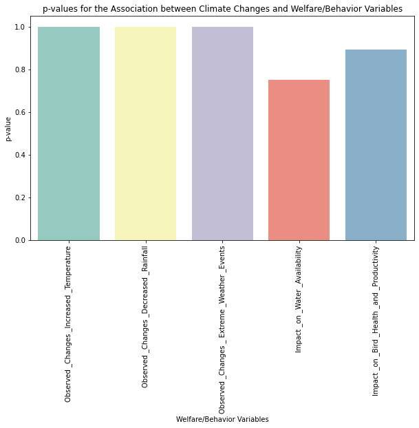

```python
# Define the variables for comparison
p_values = []
for var in welfare_behavior_vars:
    contingency_table = pd.crosstab(df['Climate_Changes _Observed'], df[var])
    chi2, p, _, _ = chi2_contingency(contingency_table)
    p_values.append(p)

plt.figure(figsize=(10, 6))
sns.barplot(x=welfare_behavior_vars, y=p_values)
plt.xlabel('Welfare/Behavior Variables')
plt.ylabel('p-value')
plt.title('p-values for the Association between Climate Changes and Welfare/Behavior Variables')
plt.xticks(rotation=90)
plt.show()
```

```
Unique values in 'Climate_Changes _Observed':
['Yes' 'No']

Unique values in 'welfare_behavior_vars':
Observed _Changes _Increased _Temperature       1
Observed _Changes _Decreased _Rainfall          1
Observed _Changes _ Extreme _Weather _Events    1
Impact _on _Water _Availability                 2
Impact _on _Bird _Health _and _Productivity     7
dtype: int64
```

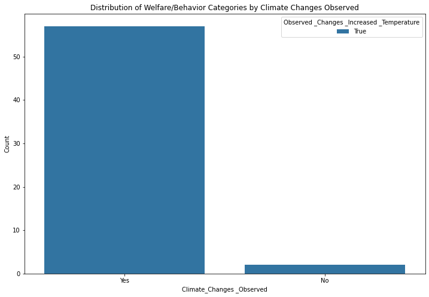

```python
# Visualize the associations between climate change observations and welfare/behavior categories
# Check unique values in the variables
print("Unique values in 'Climate_Changes _Observed':")
print(df['Climate_Changes _Observed'].unique())
print()

print("Unique values in 'welfare_behavior_vars':")
print(df[welfare_behavior_vars].nunique())
print()

# Visualize the associations between climate change observations and welfare/behavior categories
plt.figure(figsize=(12, 8))
sns.countplot(x='Climate_Changes _Observed', hue=welfare_behavior_vars[0], data=df)
plt.xlabel('Climate Changes Observed')
plt.ylabel('Count')
plt.title('Distribution of Welfare/Behavior Categories by Climate Changes Observed')
plt.legend(title=welfare_behavior_vars[0])
plt.show()
```

```python
# Encode categorical variables
farm_size_encoded = {'Less than 500 birds': 0, '500-1000 birds': 1, '1000-5000 birds': 2, 'More than 5000 birds': 3}
climate_change_encoded = {'No': 0, 'Yes': 1}

df['Farm_Size_Encoded'] = df['Farm_Size'].map(farm_size_encoded)
df['Climate_Changes_Encoded'] = df['Climate_Changes _Observed'].map(climate_change_encoded)

# Perform ANOVA
f_stat, p_value = f_oneway(df[df['Climate_Changes_Encoded'] == 0]['Farm_Size_Encoded'],
                           df[df['Climate_Changes_Encoded'] == 1]['Farm_Size_Encoded'])
print(f"Farm Size ANOVA p-value: {p_value}")
```

```
Farm Size ANOVA p-value: 0.13512939849769284
```

```python
print("Unique values in 'Farm_Size':")
print(df['Farm_Size'].unique())
```

```
Unique values in 'Farm_Size':
['More than 5000 birds' '1000-5000 birds' 'Less than 500 birds'
 '500-1000 birds']
```

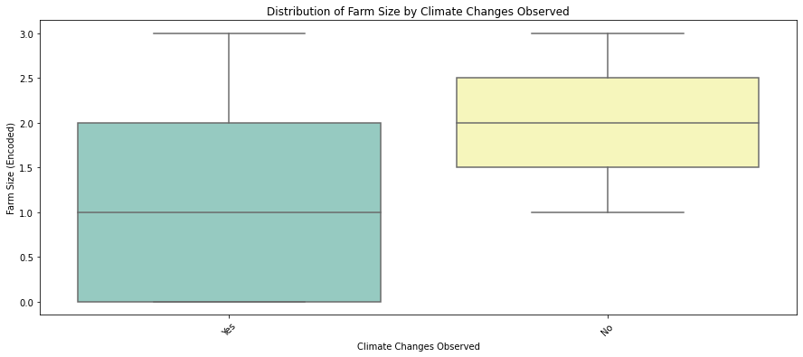

```python
farm_size_encoded = {'Less than 500 birds': 0, '500-1000 birds': 1, '1000-5000 birds': 2, 'More than 5000 birds': 3}
df['Farm_Size_Encoded'] = df['Farm_Size'].map(farm_size_encoded)

plt.figure(figsize=(15, 6))
sns.boxplot(x='Climate_Changes _Observed', y='Farm_Size_Encoded', data=df)
plt.xlabel('Climate Changes Observed')
plt.ylabel('Farm Size (Encoded)')
plt.title('Distribution of Farm Size by Climate Changes Observed')
plt.xticks(rotation=45)
plt.show()
```

## Hypothesis 3:

### The Effective Way of Mitigating Climate Change on Poultry

- #### Explore the categorical variable "Implemented_Smart_Solutions" and its relationship with the variables "Climate_Changes_Observed" and "Impact_on_Water_Availability"
- #### Utilize bar plots or stacked bar charts to compare the distribution of implemented smart solutions among different climate change observations and water availability impacts

```python
# Hypothesis 3: The Effective Way of Mitigating Climate Change on Poultry
# Cross-tabulation between climate change awareness and other variables

awareness_crosstab = pd.crosstab(df["Climate_Changes _Observed"], df[behavior_columns[0]])
print(f"Cross-tabulation between Climate_Changes_Observed and {behavior_columns[0]}:")
print(awareness_crosstab)
print()

# Perform chi-square test
chi2, p, _, _ = chi2_contingency(awareness_crosstab)
print(f"Chi-square test p-value: {p}")
print("-" * 40)
```

```
Cross-tabulation between Climate_Changes_Observed and Implemented _Smart _Solutions:
Implemented _Smart _Solutions  Evaporative cooling systems  \
Climate_Changes _Observed
No                                                       0
Yes                                                      1

Implemented _Smart _Solutions  Improved ventilation systems  \
Climate_Changes _Observed
No                                                        0
Yes                                                      22

Implemented _Smart _Solutions  Other (please specify):Change of water, addition of ice  🧊   \
Climate_Changes _Observed
No                                                                             0
Yes                                                                            1

Implemented _Smart _Solutions  Other (please specify):Frequent change of drinking water   \
Climate_Changes _Observed
No                                                                             0
Yes                                                                            1

Implemented _Smart _Solutions  Other (please specify):Giving cool drinking water during hot weather especially in the afternoon   \
Climate_Changes _Observed
No                                                                             0
Yes                                                                            1

Implemented _Smart _Solutions  Other (please specify):Heating vents  \
Climate_Changes _Observed
No                                                                0
Yes                                                               1

Implemented _Smart _Solutions  Other (please specify):Improved drinking water cooling system   \
Climate_Changes _Observed
No                                                                             0
Yes                                                                            1

Implemented _Smart _Solutions  Other (please specify):Use of ice blocks in drinking water  \
Climate_Changes _Observed
No                                                                             0
Yes                                                                            1
```

[output cut: 8 more lines]

```
No                                                                       0
Yes                                                                      1

Implemented _Smart _Solutions  Shade structures  \
Climate_Changes _Observed
No                                            1
Yes                                          16

Implemented _Smart _Solutions  Use of renewable energy sources
Climate_Changes _Observed
No                                                           1
Yes                                                          2

Chi-square test p-value: 0.6837894262059723
----------------------------------------
```

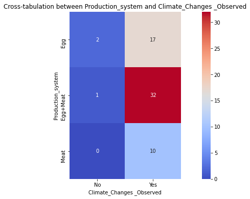

```python
# Heatmap of the cross-tabulation
plt.figure(figsize=(15, 6))
sns.heatmap(crosstab, annot=True, cmap="coolwarm", square=True)
plt.title(f"Cross-tabulation between {column} and Climate_Changes _Observed")
plt.xlabel("Climate_Changes _Observed")
plt.ylabel(column)
plt.show()
```

```
Cross-tabulation between Climate_Changes _Observed and Implemented _Smart _Solutions:
Implemented _Smart _Solutions  Evaporative cooling systems  \
Climate_Changes _Observed
No                                                       0
Yes                                                      1

Implemented _Smart _Solutions  Improved ventilation systems  \
Climate_Changes _Observed
No                                                        0
Yes                                                      22

Implemented _Smart _Solutions  Other (please specify):Change of water, addition of ice  🧊   \
Climate_Changes _Observed
No                                                                             0
Yes                                                                            1

Implemented _Smart _Solutions  Other (please specify):Frequent change of drinking water   \
Climate_Changes _Observed
No                                                                             0
Yes                                                                            1

Implemented _Smart _Solutions  Other (please specify):Giving cool drinking water during hot weather especially in the afternoon   \
Climate_Changes _Observed
No                                                                             0
Yes                                                                            1

Implemented _Smart _Solutions  Other (please specify):Heating vents  \
Climate_Changes _Observed
No                                                                0
Yes                                                               1

Implemented _Smart _Solutions  Other (please specify):Improved drinking water cooling system   \
Climate_Changes _Observed
No                                                                             0
Yes                                                                            1

Implemented _Smart _Solutions  Other (please specify):Use of ice blocks in drinking water  \
Climate_Changes _Observed
No                                                                             0
Yes                                                                            1

Implemented _Smart _Solutions  Other (please specify):Variations in stocking density   \
Climate_Changes _Observed
No                                                                             0
Yes                                                                            1

Implemented _Smart _Solutions  Other (please specify):Water cooling system  \
Climate_Changes _Observed
No                                                                       0
Yes                                                                      1

Implemented _Smart _Solutions  Shade structures  \
Climate_Changes _Observed
No                                            1
Yes                                          16

Implemented _Smart _Solutions  Use of renewable energy sources
Climate_Changes _Observed
No                                                           1
Yes                                                          2
```

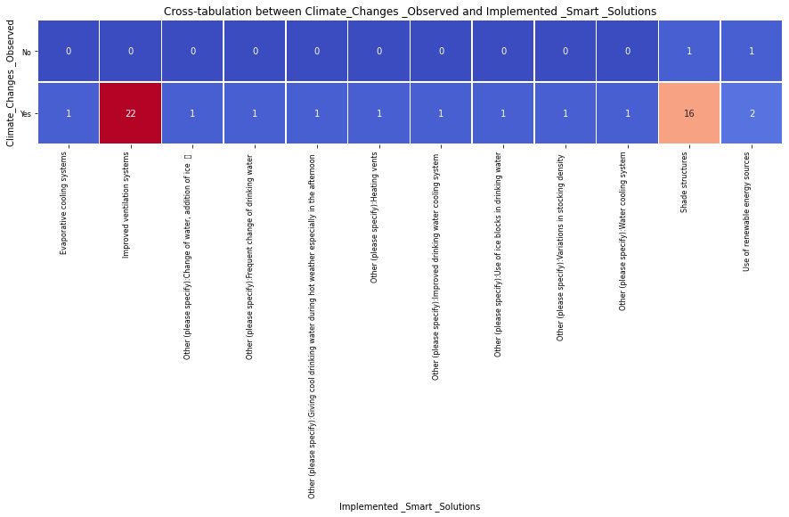

```
Chi-square test p-value: 0.6838
----------------------------------------
```

```python
# Cross-tabulation between climate change awareness and the first behavior column
awareness_crosstab = pd.crosstab(df["Climate_Changes _Observed"], df[behavior_columns[0]])
print(f"Cross-tabulation between Climate_Changes _Observed and {behavior_columns[0]}:")
print(awareness_crosstab)
print()

# Heatmap of the cross-tabulation
plt.figure(figsize=(15, 6))
heatmap = sns.heatmap(awareness_crosstab, annot=True, cmap="coolwarm", square=True, fmt="d", cbar=False,
                      linewidths=0.5, annot_kws={"size": 10})
heatmap.set_xticklabels(heatmap.get_xticklabels(), rotation=90, ha="right", fontsize=8)
heatmap.set_yticklabels(heatmap.get_yticklabels(), rotation=0, ha="right", fontsize=8)
plt.title(f"Cross-tabulation between Climate_Changes _Observed and {behavior_columns[0]}")
plt.xlabel(behavior_columns[0])
plt.ylabel("Climate_Changes _Observed")
plt.show()

# Perform chi-square test
chi2, p, _, _ = chi2_contingency(awareness_crosstab)
print(f"Chi-square test p-value: {p:.4f}")
print("-" * 40)
```

##### The chi-square test was performed to assess the independence between the variables "Climate_Changes_Observed" and "Implemented_Smart_Solutions." The obtained p-value is 0.6837894262059723.

### Interpretation:

##### The p-value obtained from the chi-square test is 0.6837894262059723, which is greater than the typical significance level of 0.05. This suggests that there no association between the variables "Climate_Changes_Observed" and "Implemented_Smart_Solutions."

##### In the cross-tabulation table, the values 0 and 1 represent the count of occurrences for each category of "Climate_Changes_Observed" (No and Yes) and each implemented smart solution. For example, for the "Evaporative cooling systems" smart solution, there are 0 occurrences for the "No" category of "Climate_Changes_Observed" and 1 occurrence for the "Yes" category.

##### Overall, the results indicate that the distribution of implemented smart solutions does not vary significantly based on the observed climate changes.

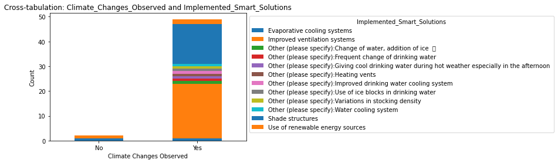

```python
plt.figure(figsize=(10, 6))
awareness_crosstab.plot(kind="bar", stacked=True)

plt.title("Cross-tabulation: Climate_Changes_Observed and Implemented_Smart_Solutions")
plt.xlabel("Climate Changes Observed")
plt.ylabel("Count")

plt.legend(title="Implemented_Smart_Solutions", bbox_to_anchor=(1, 1))
plt.xticks(rotation=0)

plt.show()
```

```python
df.columns
```

```
Index(['Establishment', 'Farm _Location ', 'Education_Level', 'Gender',
       'Production_system', 'Farm_Size', 'Years _in _Farming',
       'Egg _Preference', 'Climate_Changes _Observed',
       'Observed _Changes _Increased _Temperature',
       'Observed _Changes _Decreased _Rainfall',
       'Observed _Changes _ Extreme _Weather _Events',
       'Any _Smart _Solutions _Implemented', 'Implemented _Smart _Solutions',
       'Impact _on _Water _Availability',
       'Impact _on _Bird _Health _and _Productivity',
       'Future _of _Poultry _Farming',
       'Government _Support _Climate _Change_ Adaptation',
       'Other_ Climate _Change _Impacts', 'Farm_Size_Encoded',
       'Climate_Changes_Encoded'],
      dtype='object')
```

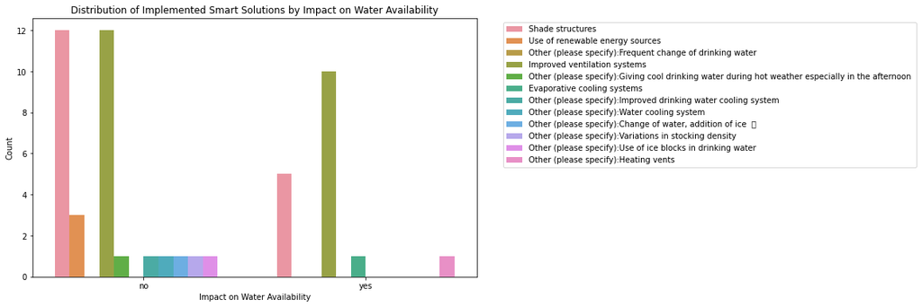

```python
# Explore the relationship between "Implemented_Smart_Solutions", "Climate_Changes_Observed", and "Impact_on_Water_Availability"
plt.figure(figsize=(10, 6))
sns.countplot(x='Impact _on _Water _Availability', hue='Implemented _Smart _Solutions', data=df)
plt.xlabel('Impact on Water Availability')
plt.ylabel('Count')
plt.title('Distribution of Implemented Smart Solutions by Impact on Water Availability')
plt.legend(title='Implemented Smart Solutions')
# Adjust legend position
plt.legend(bbox_to_anchor=(1.05, 1), loc='upper left')

plt.show()
```

## Other Insightful Distribution Patterns

```python
subset_df = df[['Education_Level', 'Gender', 'Years _in _Farming', 'Farm_Size', 'Climate_Changes _Observed']]
```

```python
subset_df['Education_Level'] = subset_df['Education_Level'].map({'Primary': 1, 'Secondary': 2, 'Tertiary': 3})
subset_df['Climate_Changes _Observed'] = subset_df['Climate_Changes _Observed'].map({'Yes': 1, 'No': 0})
```

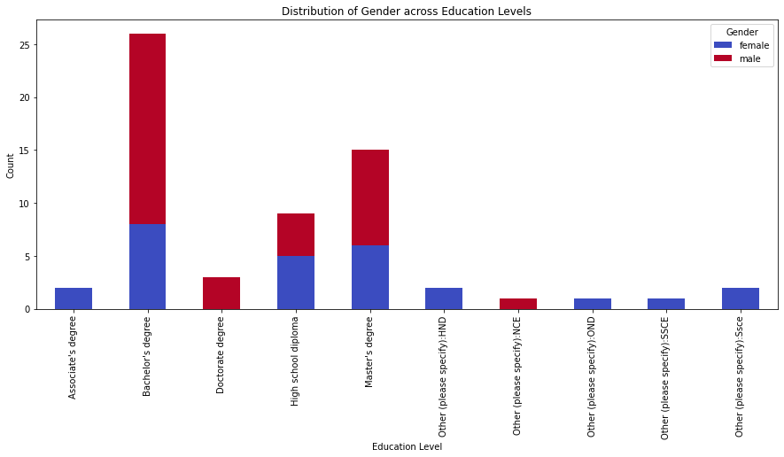

```python
# Create a stacked bar plot
cross_tab = pd.crosstab(df['Education_Level'], df['Gender'])
cross_tab.plot(kind='bar', stacked=True, colormap='coolwarm', figsize=(15, 6))

# Set labels and title
plt.xlabel('Education Level')
plt.ylabel('Count')
plt.title('Distribution of Gender across Education Levels')

# Display the plot
plt.show()
```

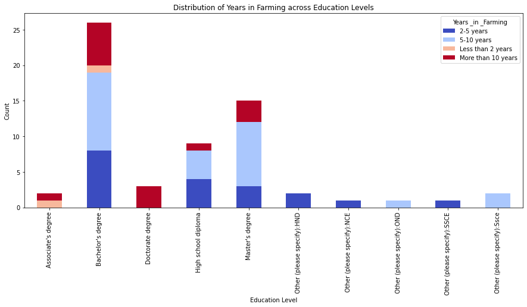

```python
# Create a stacked bar plot
cross_tab = pd.crosstab(df['Education_Level'], df['Years _in _Farming'])
cross_tab.plot(kind='bar', stacked=True, colormap='coolwarm', figsize=(15, 6))

# Set labels and title
plt.xlabel('Education Level')
plt.ylabel('Count')
plt.title('Distribution of Years in Farming across Education Levels')

# Display the plot
plt.show()
```

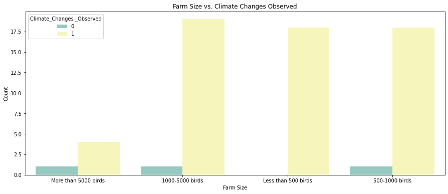

```python
plt.figure(figsize=(15, 6))
sns.countplot(x='Farm_Size', hue='Climate_Changes _Observed', data=subset_df)
plt.title('Farm Size vs. Climate Changes Observed')
plt.xlabel('Farm Size')
plt.ylabel('Count')
plt.show()
```

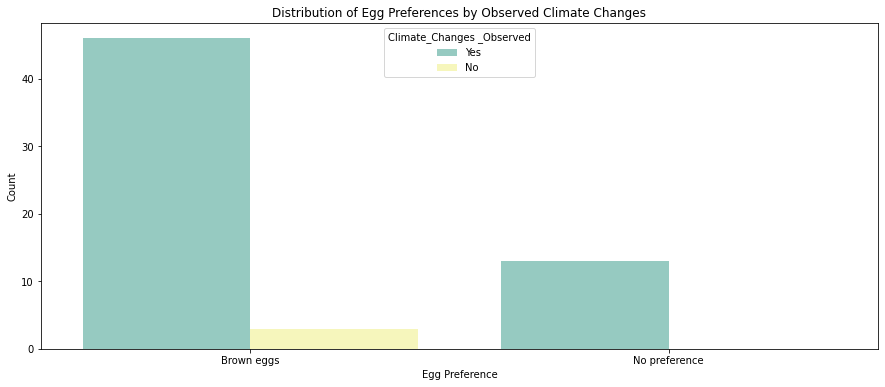

```python
plt.figure(figsize=(15, 6))
sns.countplot(data=df, x='Egg _Preference', hue='Climate_Changes _Observed')
plt.title('Distribution of Egg Preferences by Observed Climate Changes')
plt.xlabel('Egg Preference')
plt.ylabel('Count')
plt.show()
```

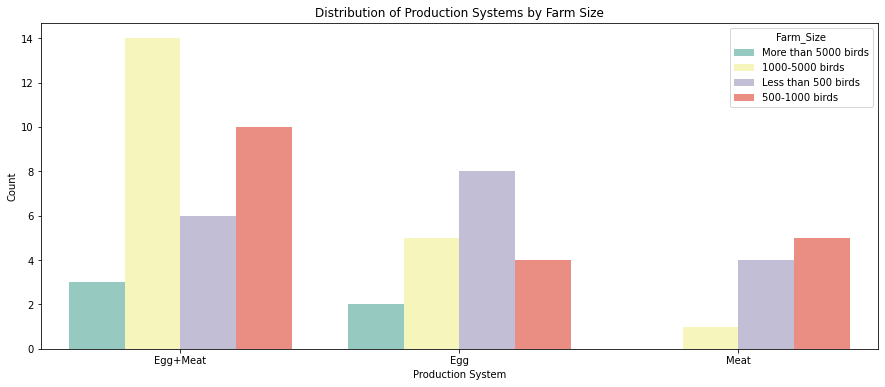

```python
plt.figure(figsize=(15, 6))
sns.countplot(data=df, x='Production_system', hue='Farm_Size')
plt.title('Distribution of Production Systems by Farm Size')
plt.xlabel('Production System')
plt.ylabel('Count')
plt.show()
```

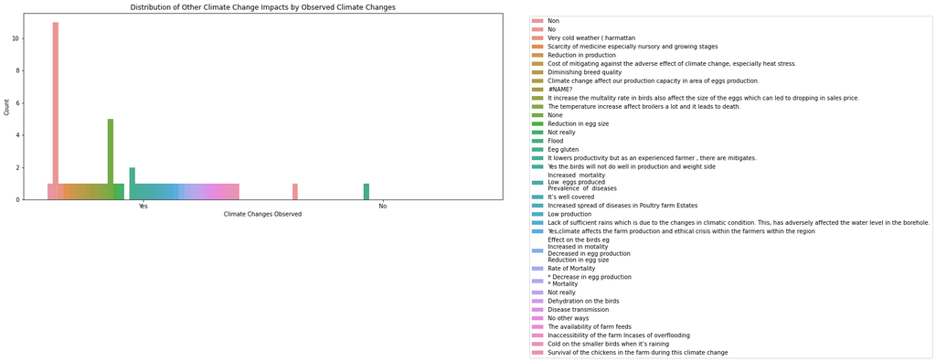

```python
plt.figure(figsize=(15, 6))
sns.countplot(data=df, x='Climate_Changes _Observed', hue='Other_ Climate _Change _Impacts')
plt.title('Distribution of Other Climate Change Impacts by Observed Climate Changes')
plt.xlabel('Climate Changes Observed')
plt.ylabel('Count')
# Adjust legend position
plt.legend(bbox_to_anchor=(1.05, 1), loc='upper left')

plt.show()
```